# Tarea 01

Víctor Augusto Samayoa Donado

CVu: 175750

Febrero 12, 2019

# 1 Inciso 1

Se procede a realizar la implementación del procedimiento inferencial PCA considerando distribuciones iniciales no informativas para $\mu$ y $\Lambda$.

```r
# Simulación
a0 <- 1
s0 <- 1
m0 <- matrix(0,ncol=1,nrow=ncol(data))
B0 <- diag(1,ncol=ncol(data),nrow=ncol(data))

gaussian.posterior <- function(data,m0,s0,a0,B0){
  xbar <- as.matrix(colMeans(data))
  S <- cov(data)
  n <- nrow(data)
  p <- ncol(data)
  # Posterior hiperparameters
  sn <- s0 + n
  an <- a0 + n/2
  mn <- (s0*m0 + n*xbar)/sn
  Bn <- B0 + (n/2)*(S + (s0/sn)*(xbar-m0)%*%t(xbar-m0))
  # Output
  output <- list(mn,sn,an,Bn)
  return(output)
}

output <- gaussian.posterior(data,m0,s0,a0,B0)

M <- 10000
mu.sim <- matrix(NA,nrow=M, ncol=ncol(data))
Lambda.sim <- array(NA,dim=c(M,ncol(data),ncol(data)))
e.sim <- matrix(NA,nrow=M, ncol=ncol(data))
V.sim <- array(NA,dim=c(M,ncol(data),ncol(data)))
C.sim <- array(NA,dim=c(M,nrow(data),ncol(data)))
m <- 1;
X <- as.matrix(data)

set.seed(95396)
for(m in 1:M){
  # Simulacion (mu,Lambda)
  Lambda.sim[m,,] <- rWishart(1, output[[3]], output[[4]])
  mu.sim[m,] <- mvrnorm(1, mu=output[[1]], Sigma=solve(output[[2]]*Lambda.sim[m,,]), tol = 1e-6)
  # Simulacion (e,V) + C
  eigen_aux <- eigen(solve(Lambda.sim[m,,]))
  e.sim[m,] <- eigen_aux$values
  V.sim[m,,] <- eigen_aux$vectors
  C.sim[m,,] <- X %*% V.sim[m,,]
}
```

En este caso se realizaron 10,000 iteraciones en la simulación la el procedimiento inferencial.

Primero, se procede a realizar un análisis de la distribución de los valores propios con el objetivo de determinar cómo poder ordenarlos.

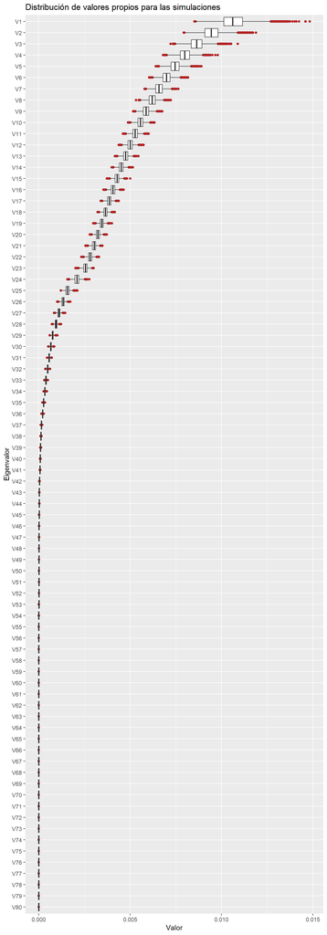

```r
as_tibble(e.sim) %>%
  gather(key = lambda, value = valor) %>%
  group_by(lambda) %>%
  mutate(mediana = median(valor)) %>%
  ungroup() %>%
  ggplot(aes(x = reorder(lambda, mediana), y = valor)) +
  geom_boxplot(outlier.colour = "firebrick") +
  labs(title = "Distribución de valores propios para las simulaciones",
       x = "Eigenvalor",
       y = "Valor") +
  coord_flip()
```

De la gráfica anterior, se puede apreciar que los eigenvalores de mayor valor son los que también presentan una mayor dispersión, esto es, una menor consistencia en las estimaciones.

Se puede decir que el eigenvector $V1$ pertenece al Top5 de los eigenvalores, sin embargo no podemos aifrmar que sea el mayor de todos. Lo mismo sucede con los demás eigenvalores.

Por tal motivo, y para efectos prácticos, se considerará el valor de la mediana para cada distribución de eigenvalores para determinar la posición de cada uno y de esta forma determinar las primeras componentes principales.

# 2 Inciso 2

Para determinar las economias que tienen mayor peso en la descomposición PCA, se utilizará el criterio de qué país tiene mayor peso en cada una de las componentes y se reportara el país para dicha componente. En el entendido que las primeras componentes son las que tienen un peso mayor global.

```r
paises <- tibble(position = 1:80,
                  pais = colnames(data))

componentes <- map_dfr(1:80, function(pais) {
  map_dfr(1:80, function(pc) {
    tibble(principal_component = pc,
           valor = mean(V.sim[,pais, pc]))
  }) %>%
    mutate(pos_pais = pais)
})

componentes %>%
  arrange(principal_component) %>%
  group_by(principal_component) %>%
  summarise(position = pos_pais[which(valor == max(valor))]) %>%
  inner_join(paises, by = "position") %>%
  DT::datatable()
```

|  | principal_component | position | pais |
| --- | --- | --- | --- |
| 1 | 1 | 26 | U.K. |
| 2 | 2 | 28 | Luxembourg |
| 3 | 3 | 39 | Portugal |
| 4 | 4 | 24 | Finland |
| 5 | 5 | 40 | Italy |
| 6 | 6 | 21 | EU12 |
| 7 | 7 | 24 | Finland |
| 8 | 8 | 41 | Greece |
| 9 | 9 | 31 | Germany |
| 10 | 10 | 40 | Italy |

[output cut: 70 more lines]

# 3 Inciso 3

A continuación de muestra la distribución de los valores de las componentes sobre todas las observaciones:

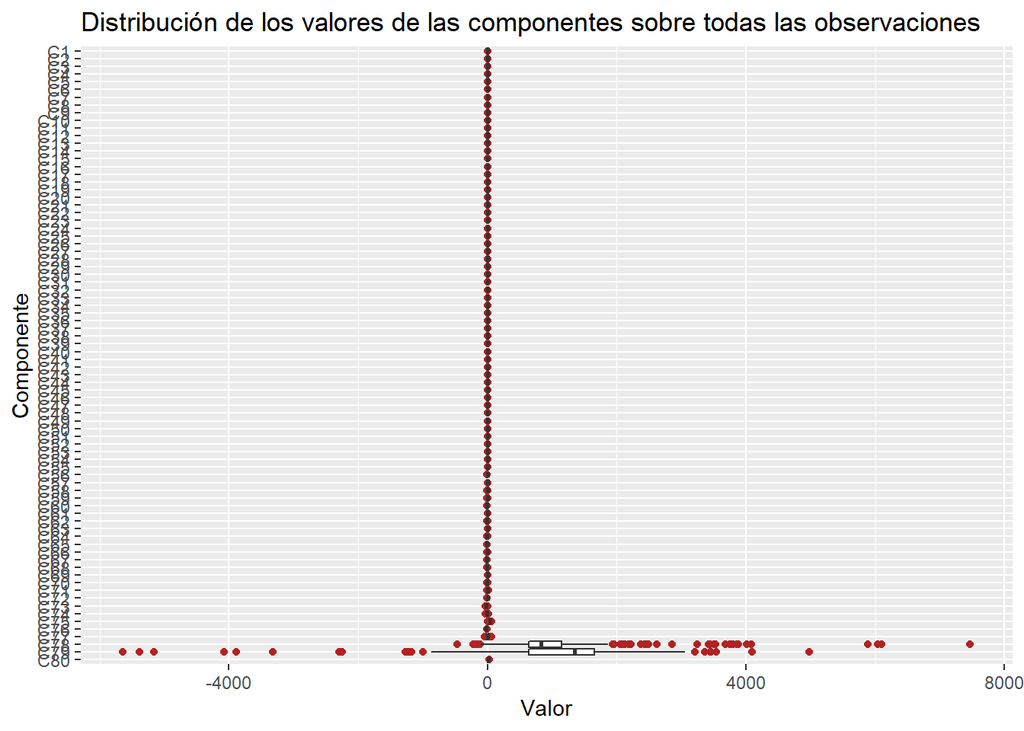

```r
desv_componentes <- map_dfr(1:80, function(variable){
  mean_var <- map_dbl(1:492, function(obs) {
    mean(C.sim[, obs, variable])
  })
  tibble(componente = variable,
         promedio = mean_var)
})

desv_componentes %>%
  arrange(componente) %>%
  mutate(lambda = paste0("C", componente)) %>%
  ggplot(aes(x = reorder(lambda, -componente), y = promedio)) +
  geom_boxplot(outlier.colour = "firebrick") +
  labs(title = "Distribución de los valores de las componentes sobre todas las observaciones",
       x = "Componente",
       y = "Valor") +
  coord_flip()
```

Como puede apreciarse las componetnes 78 y 79 son las que presentan una mayor inconsistencia.

A partir de la gráfica de eigenvalores, determinamos observar el comportamiento de las primeras 30 componentes:

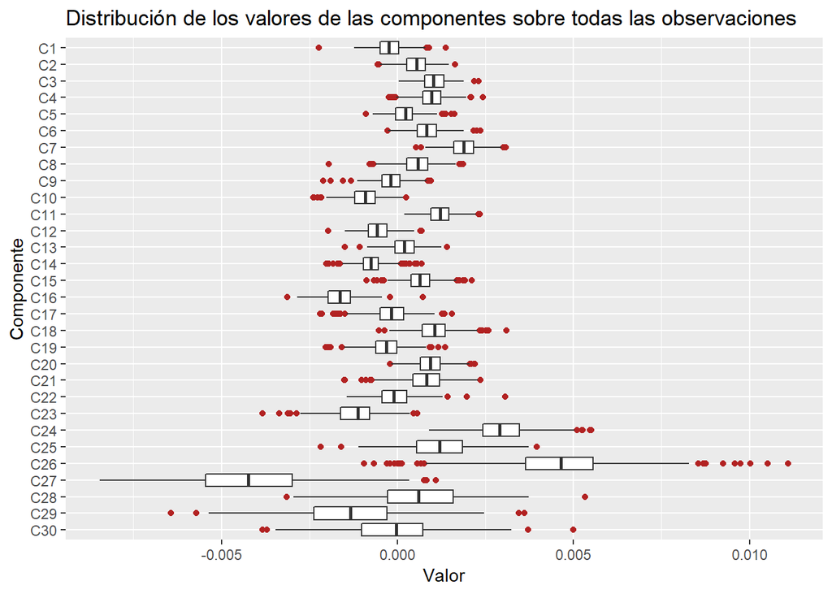

```r
desv_componentes %>%
  filter(componente <= 30) %>%
  arrange(componente) %>%
  mutate(lambda = paste0("C", componente)) %>%
  ggplot(aes(x = reorder(lambda, -componente), y = promedio)) +
  geom_boxplot(outlier.colour = "firebrick") +
  labs(title = "Distribución de los valores de las componentes sobre todas las observaciones",
       x = "Componente",
       y = "Valor") +
  coord_flip()
```

Se puede apreciar que las primeras componentes son, en términos generales, las más consistentes.